# Muestreo y modelado

## Introducción al muestreo

> Sampling is not mere substitution of a partial coverage for a total coverage. Sampling is the science and art of controlling and measuring the reliability of useful statistical information through the theory of probability — William Edwards Deming.

Como hemos visto hasta ahora, el proceso científico de análisis de datos y descubrimiento de información se detona con una pregunta de investigación. Esta pregunta determinará, entre otras cosas, la población de interés, así como el nivel de precisión que deseamos obtener de nuestras estimaciones. Si consideramos la incompletud de la información proveniente de la naturaleza inherente de los datos, componentes temporales, físicos o tecnológicos, es evidente que, independientemente de que nuestros objetivos sean: realizar análisis exploratorio, inferencial, predictivo o prescriptivo, siempre estaremos limitados a trabajar con subconjuntos de la población (muestras), en lugar de con el total de la población. Inherentemente, esto introducirá incertidumbre en nuestros estimados y, con ello, la necesidad de implementar metodologías que nos ayuden a cuantificarla.

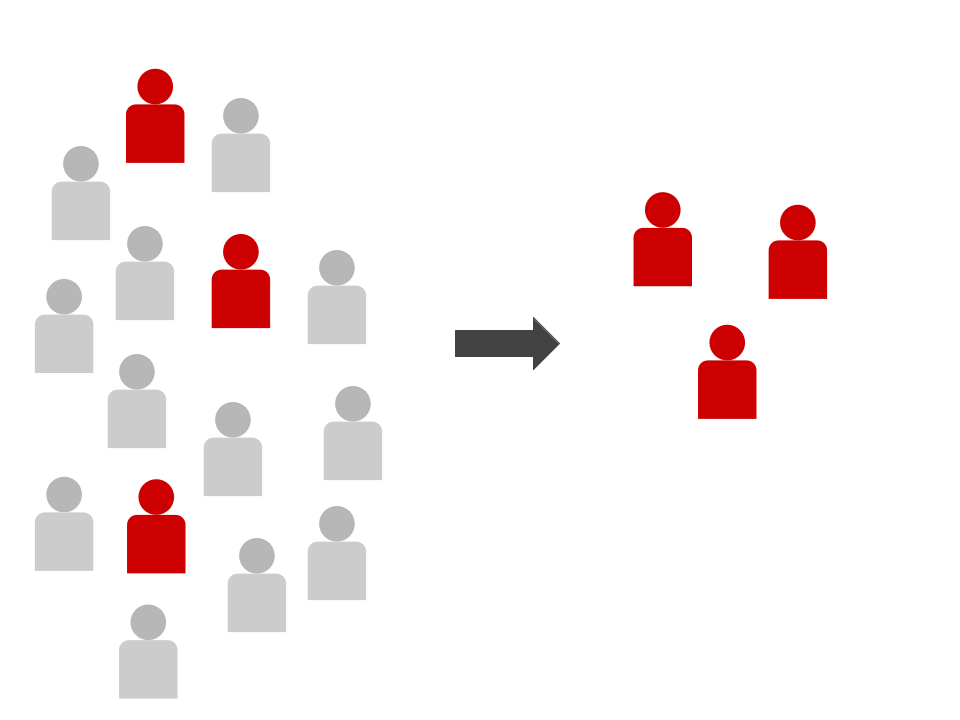

Con esto en mente, sería deseable que la muestra bajo estudio ‘refleje’, en la medida de lo posible, las características de la población —específicamente aquéllas que creemos que son relevantes para la pregunta en cuestión. Para precisar las características de una ‘buena’ muestra, es necesario familiarizarnos con las siguientes definiciones:

**Unidad de observación** Es un objeto sobre el cual se obtiene una medida determinada. Es la unidad más básica de información.

**Población objetivo** Es el conjunto total de observaciones que se desean estudiar. Por ejemplo, en una encuesta para determinar tendencias electorales, la población objetivo podría estar definida por: Todos los adultos con capacidad de voto, todos los votantes registrados o las personas que votaron en la eleeción pasada. La elección de la población objetivo tendrá repercusiones importantes en los resultados estadísticos.

**Muestra** Un subconjunto de la población.

**Población muestreada** El total de observaciones que pudieron haber sido seleccionadas dentro de la muestra. Por ejemplo, si quisieramos obtener la opinión de todos los protestantes con respecto a cierto tema, podríamos limitarnos a muestrear a los feligreces de iglesias protestantes.

**Unidad de muestreo** Una unidad que puede ser seleccionada para una muestra. Podríamos estar interesados en estudiar a todos los individuos de un país; sin embargo, difícilmente se cuenta con un listado de dichos individuos. Una alternativa es definir los ‘hogares’ como unidades de muestreo. En ese mismo ejemplo, las unidades de observación serán los individuos que habitan dentro de dichos hogares.

**Encuadre de muestreo** Una lista, un mapa o cualquier otra especificación de unidad de muestreo en la población sobre la cual se seleccionará la muestra. E.g. una lista de teléfonos, correos, registros prediales, etc.

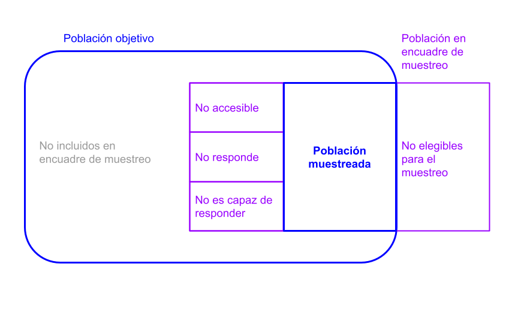

Sampling Framework. Lohr, Sharon L. Sampling: design and analysis. Chapman and Hall/CRC, 2019.

Idealmente, la población muestreada debe reflejar las caraterísticas de la población objetivo. Sin embargo, esto es más difícil de lograr de lo que parece. Cuando las unidades de una población se muestrean con una frecuencia diferente a la requerida por el experimento, se incurre en un **sesgo de selección**. Sesgos de selección pueden ocurrir de diversas maneras:

- Muestreo de conveniencia: se muestrean las unidades que son más fáciles de seleccionar o que son más probables de responder a las preguntas.
- Muestreo por juicio: la muestra se toma de tal manera que ésta soporte la hipótesis que se desea probar. Por ejemplo, si buscamos obtener el monto promedio que los individuos destinan a compras, sólo encuestamos a aquéllos individuos que parece han comprado un monto ‘promedio’ de artículos.
- Malas especificaciones en la población objetivo.
- Sub-cobertura: fragmentos de la población objetivo no son consideradas dentro del encuadre de muestreo. Personas que no tienen teléfono, por ejemplo.
- Sobre-cobertura: Incluir personas en el encuadre de muestreo que no están consideradas en la población objetivo. Un ejemplo: encuestar a personas que no tienen credencial para votar.
- Falta de respuesta: por lo regular, los individuos que no responden tienen características muy diferentes a la población que sí lo hace.

Denominaremos a este tipo de sesgos, junto con los sesgos que podrían derivarse de ‘errores de medición’, como **errores fuera de muestra**; es decir, no se pueden asociar a la variabilidad intrínseca entre muestras. Mientras que a los errores que se producen por el simple hecho de tomar muestras en lugar del total de la población, los llamaremos **errores dentro de la muestra**.

A continuación, estudiaremos las diferentes maneras en las que podemos obtener muestras, reduciendo los distintos tipos de sesgos.

## Métodos de muestreo

Dado que queremos reducir los sesgos ocasionados por el proceso de muestreo lo más posible, en este curso nos enfocaremos en **muestreo probabilístico**. En este tipo de muestreos, cada unidad tiene una probabilidad conocida de selección, así como un mecanísmo aleatorio para determinar qué unidades serán incluidas dentro de la muestra. Si el diseño de un muestreo probablístico es implementado de manera adecuada, se pueden utilizar muestras relativamente pequeñas para hacer inferencias sobre poblaciones arbitrariamente grandes.

### Muestreo aleatorio simple

Un muestreo aleatorio simple (SRS por sus siglas en inglés) de tamaño $n$ ocurre cuando cualquier subconjunto de $n$ unidades dentro de la población tiene la misma probabilidad de ocurrir dentro de la muestra. Este esquema de muestreo es la base para esquemas más complicados. De manera concreta, sea $U=\{1, 2, \dots, N\}$ el universo o población objetivo. Denotaremos por $S_n=\{u_1, u_2, \dots, u_n\}$ a una muestra de tamaño $n$. Definimos por $\pi_i = P(u_i\in S_n)$ la probabilidad de que la unidad $i$ sea incluida dentro de la muestra. Es claro que podemos obtener $\pi_i$ simplemente calculando el total de muestras que contienen a $u_i$ y dividirlo entre el total de muestras que pueden ser obtenidas dentro de la población.

Hay dos maneras en las cuales podemos realizar muestreo aleatorio simple. **Con reemplazo**, en donde cada unidad es regresada a la población, después de haber sido registrada (i.e. en este esquema se aceptan repeticiones), y por tanto produce la ilusión de una población ‘infinita’. Y **sin reemplazo**, en donde todas las unidades dentro de la muestra son distintas. De esta forma, en un esquema de muestreo sin reemplazo en el que se desea obtener una muestra de tamaño $n$, todo conjunto de $n$ unidades, tiene la misma proabilidad de ser seleccionado, dado que hay $N \choose n$$=\frac{N!}{(N-n)!n!}$ posibles muestras de aquí que la probabilidad de escoger una muestra en específico es $P(S)=\frac{1}{N \choose n}$. Es importante notar que para ajustar la varianza de los estimadores por los efectos de población finita, agregaremos el multiplicador $(1-\frac{n}{N})$.

Ejercicio 1.1

Supongamos que nuestra población de interés son todas las letras del abecedario: `letters` Obtén con simulación $\pi_u=P(u\in S_4)$ y compáralo con el resultado analítico.

- HINT 2: `letters`
- HINT 1: `gtools::combinations()`

```r
## (25 C 3) /(26 C 4)
combs = combinations(26, 4, letters)
print(sum(apply(combs, 1, function(t) 'u' %in% t))/dim(combs)[1])
```

```
## [1] 0.1538462
```

Recordando el módulo pasado: cuando tenemos una muestra, en el mayor de los casos, vamos a estar interesados en ciertas cantidades que encapsulan la tendencia y dispersión de la distribución poblacional. Estas cantidades se llaman estadísticos.

Ejercicio 1.2.a

Supongamos que queremos estimar el total de letras que componen los prefijos de los correos de alumnos en esta clase. Obtén una muestra de 5 alumnos y calcula el estadístico: $\hat{t}=\frac{N}{5}\displaystyle\sum_{i=1}^5l_i$ en donde $N$ es el número de alumnos, y $l_i$ es el número de letras en el prefijo $i$.

```r
samp_size <- 5
# Read in data
alumns <- read.csv('./data/alumnos.txt')
# Nombres a longitud
names <- map_int(apply(alumns, 1,
                       function(t) str_split(t, '@')[[1]][1]),
                 ~length(str_split(str_replace_all(., '\\.', ''), '')[[1]]))
# Muestra
samp <- sample(names, size=samp_size)
# Stat
stat <- length(names)*sum(samp)/samp_size
stat
```

```
## [1] 441.6
```

Ejercicio 1.2.b

Genera un histograma con la distribución del estadístico $\hat{t}$ sobre todas las posibles muestras de tamaño 5.

- HINT 1: combinations(set=F)

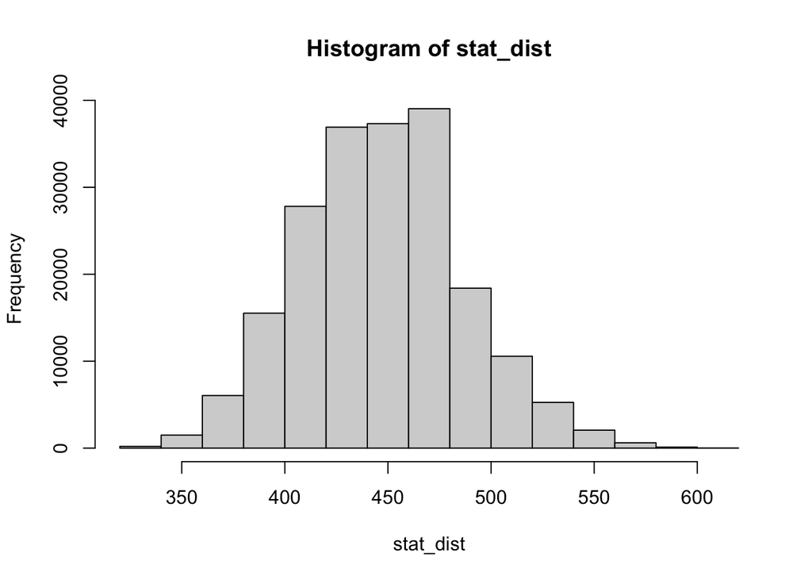

```r
samps <- combinations(length(names), 5, names, set=F)
stat_dist <- apply(samps, 1, function(t) length(names)*sum(t)/samp_size)
hist(stat_dist)
```

- ¿Cuál es el valor esperado de $\hat{t}$, $E(\hat{t})=\displaystyle\sum_{i=1}^niP(\hat{t}=i)$, y cómo se compara con el valor poblacional?

```r
print(paste('mean(t):', mean(stat_dist)))
```

```
## [1] "mean(t): 447"
```

```r
print(paste('pop t', sum(names)))
```

```
## [1] "pop t 447"
```

- ¿Cuál es la varianza de $\hat{t}$, $V(\hat{t})=E[(\hat{t}-E(\hat{t}))^2]$

```r
print(paste('var(t):', var(stat_dist)))
```

```
## [1] "var(t): 1599.62729832402"
```

```r
# Notar que podríamos obtener la varianza de la distribución de los promedios
# y simplemente multiplicarla por N**2
```

Como podemos observar, el valor esperado de nuestro estadístico es exactamente igual al parámetro poblacional. En este tipo de situaciones, decimos que nuestro estimador es insesgado.

Definimos el sesgo de un estadístico $\hat{\theta}$ para un parámetro poblacional $\theta$ como

$Bias(\hat{\theta})=E(\hat{\theta}) - \theta$

De la misma manera, definimos el error cuadrático medio de un estimador como:

$$\begin{aligned}
MSE(\hat{\theta}) &=
E[(\hat{\theta}-\theta)^2] \\
&= V(\hat{\theta}) + Bias(\hat{\theta})^2
\end{aligned}$$
Con estas medidas, podemos caracterizar la naturaleza de la diferencia que existe entre nuestros estimadores y los parámetros poblacionales. De esta forma, podemos clasificar:

- Insesgados si $E(\hat{\theta})=\theta$
- Exacto si $V(\hat{\theta})$ es pequeña
- Preciso si $MSE(\hat{\theta}) = E[(\hat{\theta}-\theta)^2]$

El siguiente diagrama ilustra la diferencia entre dichas métricas.

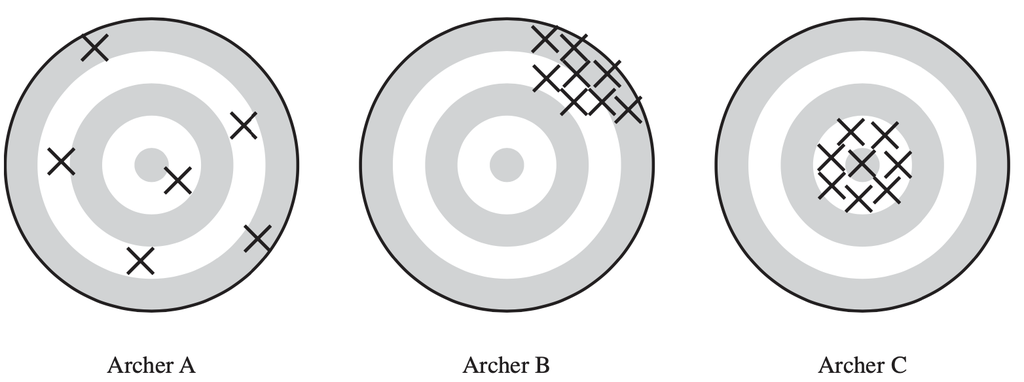

Desafortunadamente, en la práctica no podemos extraer muestras de manera arbitraria y, por tanto, resulta imposible cuantificar de manera absoluta las propiedades de nuestros estimadores; por ello, tendremos que conformarnos con una única muestra y descansar en resultados estadísticos que nos permitan diagnosticar la precisión y exactitud de nuestros estimados. Repasemos el caso de la media muestral.

Tomemos por ejemplo la media muestral:

$\bar{x}=\hat{\theta}=\frac{1}{n}\displaystyle\sum_{i=1}^nx_i; x_i\in S$

Sabemos que la varianza de $\bar{x}$ está dada por:

$V(\bar{x})=\frac{s^2}{n}(1-\frac{n}{N})$

En donde $s^2= \frac{1}{n-1}\displaystyle\sum_{i=1}^n(x_i - \bar{x})$ es el estimador insesgado para la varianza y el factor $(1-\frac{n}{N})$ nos ayuda a corregir efectos de tamaño de muestra. Si la muestra es suficientemente grande, tendremos mayor información sobre el fenómeno bajo estudioy , por tanto, la varianza debe disminuir. Recordemos que el **error estándar** de un estimador se define como la raíz cuadrada de la varianza muestral de dicho estimador.

$SE(\bar{x})=\sqrt{V(\bar{x})}=\sqrt{(1-\frac{n}{N})\frac{s^2}{n}}$

Una métrica bastante útil, que es independiente de la unidad de medida, es el **coeficiente de variación**.

$\hat{CV}=\frac{SE(\bar{x})}{\bar{x}}$

Éste nos brinda un indicador de qué tanto varía nuestro estimador con respecto a su tendencia central.

Ejercicio 1.3

Obtén estimadores para: población promedio, población total, grado promedio de escolaridad, así como el error estándar y el coeficiente de variación a partir de una muestra de 500 localidades.

- HINT 0: Usa el diccionario de datos.
- HINT 1: Nota que hay registros que contemplan totales.
- HINT 2: Elimina valores nulos para las variables de interés.
- HINT 3: $\hat{t}=N\bar{x}$.
- HINT 4: $V(na)=n^2V(a)$

**Paso 1: Lectura de datos**

```r
## --------------------------------
## Leer datos
## - pasar nombres a minúsculas
## - declarar  '*' como na
## - parsear numeros
## - select variables de interés
## - eliminar valores nulos
## --------------------------------
```

```r
locs <- (read_csv('./data/census.csv') %>%
           rename_with(tolower) %>%
           select(nom_ent, entidad, longitud, pobtot, graproes,
                  graproes_f, graproes_m) %>%
           na_if('*') %>%
           mutate(longitud = parse_number(longitud),
                  graproes = parse_number(graproes),
                  graproes_f = parse_number(graproes_f),
                  graproes_m = parse_number(graproes_m)) %>%
           drop_na())
head(locs)
```

```
## # A tibble: 6 x 7
##   nom_ent        entidad longitud pobtot graproes graproes_f graproes_m
##   <chr>          <chr>      <dbl>  <dbl>    <dbl>      <dbl>      <dbl>
## 1 Aguascalientes 01           102 863893    11.0       10.9       11.1
## 2 Aguascalientes 01           102     41     8.42       9.29       7.71
## 3 Aguascalientes 01           102   1169     8.04       7.85       8.22
## 4 Aguascalientes 01           102     41     6          6.5        5.38
## 5 Aguascalientes 01           102   1054     8.05       8.1        8.01
## 6 Aguascalientes 01           102    192     7.46       7.61       7.29
```

**Paso 2: Generar muestra y crea una función para obtener los estadísticos**

```r
## --------------------------------
## Stats
## (1-n/N)
## ----------------------------
get_stats <- function(df, N, n){
  (df %>% summarise(mean_pop = mean(pobtot),
              s_square_pop = var(pobtot),
              var_mean_pop = (1-n/N)*(s_square_pop/n),
              se_mean_pop = sqrt(var_mean_pop),
              cv_mean_pop = se_mean_pop/mean_pop,
              tot_pop = N*mean_pop,
              var_tot_pop = N**2*var_mean_pop,
              cv_tot_pop = sqrt(var_tot_pop)/tot_pop,
              mean_grap = mean(graproes),
              s_square_grap = var(graproes),
              var_mean_grap = (1-n/N)*(s_square_grap/n),
              se_mean_grap = sqrt(var_mean_grap),
              cv_mean_grap = se_mean_grap/mean_grap
    ))
}
stats <- get_stats(locs_samp, N, n)

head(stats)
```

```
## # A tibble: 1 x 13
##   mean_pop s_square_pop var_mean_pop se_mean_pop cv_mean_pop tot_pop var_tot_pop
##      <dbl>        <dbl>        <dbl>       <dbl>       <dbl>   <dbl>       <dbl>
## 1     544.     6161324.       12266.        111.       0.204  5.88e7     1.44e14
## # … with 6 more variables: cv_tot_pop <dbl>, mean_grap <dbl>,
## #   s_square_grap <dbl>, var_mean_grap <dbl>, se_mean_grap <dbl>,
## #   cv_mean_grap <dbl>
```

¿Cómo se comportan los estimadores con respecto a los ‘valores reales’ del censo?

Obtener mean_pop, tot_pop, mean_grap para toda la población.

```r
print(paste('Estimador: ',  mean(locs_samp$pobtot), 'Valor poblacional: ',  mean(locs$pobtot)))
```

```
## [1] "Estimador:  543.666 Valor poblacional:  1161.07498960018"
```

```r
print(paste('Estimador: ', N*mean(locs_samp$pobtot), 'Valor poblacional: ', sum(locs$pobtot)))
```

```
## [1] "Estimador:  58811069.55 Valor poblacional:  125599287"
```

```r
print(paste('Estimador: ', mean(locs_samp$graproes), 'Valor poblacional: ', mean(locs$graproes)))
```

```
## [1] "Estimador:  6.72828 Valor poblacional:  6.691908943841"
```

¿Qué pasa con nuestro estimador de población total?

¿Notas alguna relación interesante entre $CV(\hat{t})$ y $CV(\bar{p})$?

Vemos que el estimador para grado de escolaridad se comporta bastante bien, mientras que el estimador de población total está muy alejado del valor real. Algunas de las causas que pueden explicar esto son las siguientes:

1. Demasiada variabilida a lo largo de ‘estratos’ que no están siendo tomados en cuenta, por ejemplo entidad federativa.
2. Demasiado sesgo en la distribución de totales.

Ejercicio 1.4

¿Cómo se encuentra representada la población de diferentes entidades federativas con respecto a la población de cada entidad, dentro de tu muestra?

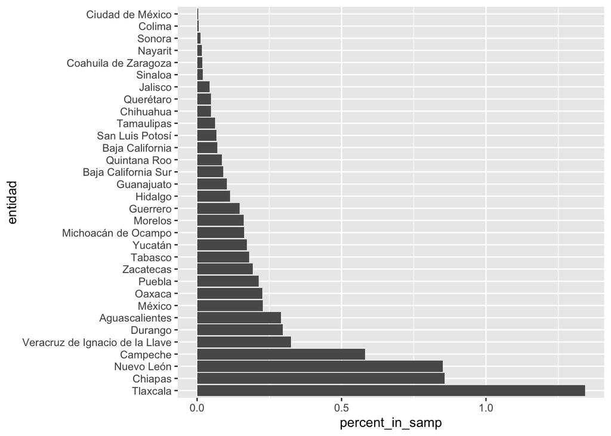

```r
(locs_samp %>%
   group_by(nom_ent) %>%
   summarise(pobtot_samp = sum(pobtot)) %>%
   left_join((locs %>%
           group_by(nom_ent) %>%
           summarise(pobtot = sum(pobtot))), by='nom_ent') %>%
   mutate(percent_in_samp = pobtot_samp/pobtot*100)
 ) %>%
   ggplot(.) + geom_bar(aes(x=reorder(nom_ent, -percent_in_samp), y = percent_in_samp), stat='identity') + xlab('entidad') +  coord_flip()
```

Claramente, podemos observar que las diferentes entidades no están representadas de manera uniforme con respecto a su población. Esto es una consecuencia natural de haber realizado un muestreo aleatorio simple, en lugar de generar estratos para variables de interés. Es importante notar que si nosotros intentamos equilibrar este muestreo, existe el riesgo de que quitemos el ruido generado por la desproporción geográfica, pero introduzcamos otro tipo de sesgos, como la distribución por sexo o edad. En la siguiente sección, veremos cómo llevar a cabo este tipo de muestreos controlando por variables de interés.

2. La distribución de datos está demasiado sesgada.

Ejercicio 1.5

Grafica la distribución de población total y grado de escolaridad dentro de la muestra.

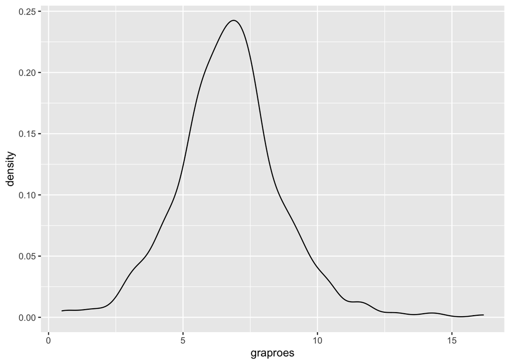

```r
ggplot(locs_samp)  + geom_density(aes(x=graproes))
```

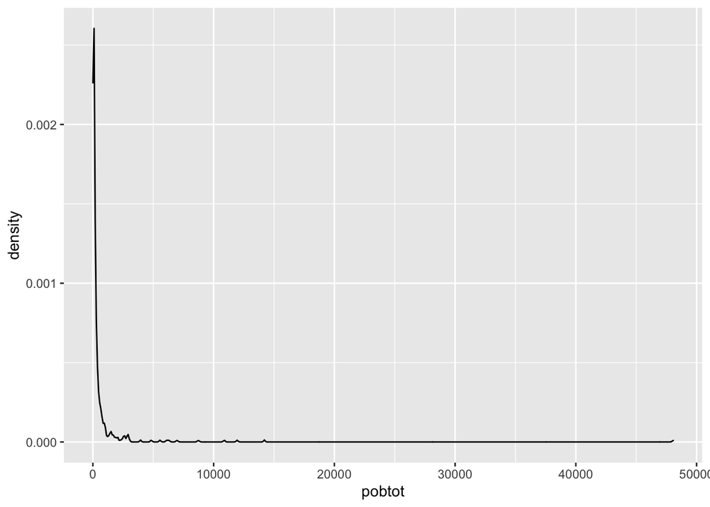

```r
ggplot(locs_samp)  + geom_density(aes(x=pobtot))
```

Vemos que la variable de grado de escolaridad tiene un comportamiento bastante similar a una distribución normal, mientras que la variable de población total está altamente sesgada.

Ejercicio 1.6

Realiza un qqplot usando ambas distribuciones vs una distribución normal.

Veremos que esto tiene consecuencias importantes a la hora de definir un grado de precisión específico para nuestros estimados, lo cual está directamente ligado con exigencias sobre el tamaño de muestra necesario para adquirirlo.

#### Tamaño de muestra en muestreo aleatorio simple

> As we frame it, the goal of design is not to attain statistical significance with some high probability, but rather to have a sense (before and after data have been collected) about what can realistically be learned from statistical analysis of an empirical study — Aki Vehtari.

Dentro de todas las problemáticas que podemos abordar durante cualquier análisis estadístico, identificar el tamaño necesario de una muestra para poder estimar una medida poblacional con un nivel de precisión determinado es quizá la que tendrá un mayor impacto sobre la confiabilidad y validez de nuestros resultados. Si bien esta tarea tiende a asociarse con el paradigma inferencial que busca estimar estadísticos poblacionales a partir de encuestas, efectos a partir de experimentos o estudios observacionales, la aplicación de sus principios abarca otros objetivos inferenciales como predicción o reducción de datos.

Recordando el módulo anterior, hay una serie de resultados que nos permiten determinar la precisión de nuestros estimadores. En el caso particular de la media muestral $\bar{x}$, por ejemplo, sabemos que si se cumplen ciertos requerimientos técnicos, como independencia y N, n, N-n >>0:

$\frac{\bar{x}-\mu}{\sqrt{(1-\frac{n}{N})}\frac{S}{\sqrt{n}}}\sim N(0, 1)$

Por lo tanto, podemos definir intervalos de confianza de $100(1-\alpha)\%$ de la siguiente manera:

$\big[\bar{x}-z_{\frac{\alpha}{2}}\sqrt{(1-\frac{n}{N})}\frac{S}{\sqrt{n}}, \bar{x}+z_{\frac{\alpha}{2}}\sqrt{(1-\frac{n}{N})}\frac{S}{\sqrt{n}} \big]$

En la práctica, dado que en la mayor parte de los casos la varianza es desconocida, se reemplazan los cuantiles de la normal $(0,1)$ por los cuantiles de una distribución $t$ con $n-1$ grados de libertad. Para este tipo de intervalos, por lo regular se cita $n=30$ como el número mágico para que los supuestos del TCL empiecen a aplicar; sin embargo, el tamaño de muestra también puede definirse con base en requisitos de precisión o de certidumbre. El método más sencillo procede definiendo rangos de tolerancia $\epsilon$ de manera equivalente a como se hace con los intervalos de confianza:

$P(|\bar{x} - \mu|<\epsilon)=(1-\alpha)\%$

Lo que se puede hacer, entonces, es igualar a epsilon con los límites conocidos del intervalo:

$\epsilon = z_{\frac{\alpha}{2}}\sqrt{(1-\frac{n}{N})}\frac{S}{\sqrt{n}}$

Suponiendo que estamos realizando muestreo simple con reemplazo, podemos primero resolver:

$$\begin{aligned}
\epsilon &=(\frac{Sz_{\frac{\alpha}{2}}}{\sqrt{n_0}})\\
\Rightarrow\\
n_0 & = (\frac{Sz_{\frac{\alpha}{2}}}{\epsilon})^2
\end{aligned}$$
y luego corregir por muestras finitas usando:

$n=\frac{n_0}{1+\frac{n_0}{N}}$

Ejercicio 1.7

Genera un intervalo de 95% de confianza para el estimador de grado de escolaridad, con presición de .03 y .001.

```r
epsilon <- .03
alpha <- .05
n0 <- stats$s_square_grap*(qnorm(1-alpha/2)/epsilon)**2
n <- n0/(1+(n0/N))
print(paste('epsilon: ', epsilon, '0 => n:', n))
```

```
## [1] "epsilon:  0.03 0 => n: 14535.3627160408"
```

```r
locs_samp_1 <- locs[sample(N, n), ]
stats <- get_stats(locs_samp_1, N, n)
```

```r
CI_graps <- c(stats$mean_grap - qt(1-alpha/2, n-1)*stats$se_mean_grap,
              stats$mean_grap + qt(1-alpha/2, n-1)*stats$se_mean_grap)
print(paste('pop param:', mean(locs$graproes)))
```

```
## [1] "pop param: 6.691908943841"
```

```r
CI_graps
```

```
## [1] 6.680467 6.740534
```

```r
epsilon <- .001
alpha <- .05
n0 <- stats$s_square_grap*(qnorm(1-alpha/2)/epsilon)**2
n <- n0/(1+(n0/N))
print(paste('epsilon: ', epsilon, '0 => n:', n))
```

```
## [1] "epsilon:  0.001 0 => n: 107407.767446888"
```

```r
locs_samp_2 <- locs[sample(N, n), ]
stats <- get_stats(locs_samp_2, N, n)
```

```r
CI_graps <- c(stats$mean_grap - qt(1-alpha/2, n-1)*stats$se_mean_grap,
              stats$mean_grap + qt(1-alpha/2, n-1)*stats$se_mean_grap)
print(paste('pop param:', mean(locs$graproes)))
```

```
## [1] "pop param: 6.691908943841"
```

```r
CI_graps
```

```
## [1] 6.691417 6.693432
```

Es claro que mientras mayor certeza y precisión pidamos a nuestros estimadores, mayor deberá de ser el tamaño de la muestra. Aunado a esto, en distribuciones con mucho sesgo, Sugden et al. (2000) sugieren definir el tamaño de muestra mínimo de la siguiente manera:

$n_{min}=28 + 25 \Big(\frac{\displaystyle\sum_{i=1}^N{(x_i - \bar{x})^3}}{NS^3}\Big)^2$

Vemos que el término al cuadrado es el sesgo de la distribución. Por lo tanto, distribuciones que tengan mucho sesgo requerirán un tamaño de muestra mayor que el de aquéllas que estén más centralizadas.

Ejercicio 1.8

Actualiza el tamaño de muestra utilizadno la fórmula para distribuciones altamente sesgadas y obtén el estimador de población total, así como un intervalo de 95% de confianza empleando el método bootstrap y usando 500 muestras bootstrap. Grafica la distribución de los valores bootstrap así cómo los intervalos de confianza.

```r
n_min <- 28 + 25*skewness(locs_samp$pobtot)**2
n <- n_min
print(paste('min n:', n_min))
```

```
## [1] "min n: 5618.81226868404"
```

```r
locs_samp <- locs[sample(N, n), ]
stats <- get_stats(locs_samp, N, n)
stats$tot_pop
```

```
## [1] 107761959
```

```r
B <- 500
B_estimates <- map_dbl(seq(B), ~N*mean(sample(locs_samp$pobtot, n, replace=T)))
CI <- c(quantile(B_estimates, alpha/2), quantile(B_estimates, 1-alpha/2))
CI
```

```
##      2.5%     97.5%
##  71121844 151826169
```

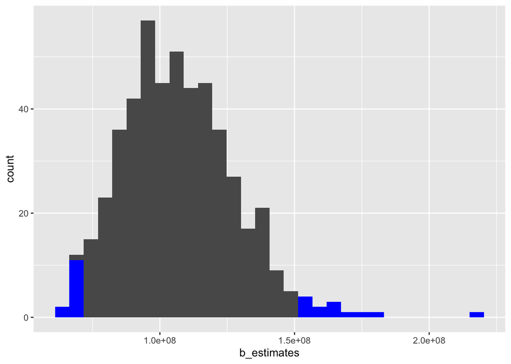

```r
B_data <- tibble(b_estimates = B_estimates)
(B_data %>% ggplot(.) +
   geom_histogram(aes(x=b_estimates)) +
   geom_histogram(data=B_data %>% filter(b_estimates < CI[1]), aes(x=b_estimates), fill='blue') +
    geom_histogram(data=B_data %>% filter(b_estimates > CI[2]), aes(x=b_estimates), fill='blue')
   )
```

### Muestreo estratificado

A pesar de que un muestreo aleatorio simple nos permite generar inferencias sobre la distribución de datos, hay una serie de motivos por los cuales podría resultar atractivo particionar nuestra colección de datos a lo largo de una serie de variables que nos permitan generar ‘estratos’ más uniformes. Algunos de los motivos por los cuales resulta conveniente llevar a cabo muestreo estratificado son los siguientes:

- **Evitar muestras no representativas**: Supongamos que tenemos un conjunto de datos de 1000 unidades, en donde la mitad de los individuos son hombres y la mitad mujeres. Si extraemos una muestra de 100 observaciones, existe la posibilidad de que una de las dos sub-poblaciones esté mal representada, incluso al extremo de no contener observaciones de una de éstas.
- **Datos mal balanceados**: Si queremos tener estimadores de precisión similares entre dos sub-poblaciones y una de ellas se encuentra con mucha menor frecuencia dentro de la población, una posible estrategia sería sobremuestrear el estrato que está subrepresentado.
- **Mayor flexibilidad de diseño**: Si sabemos que algunos estratos son más fáciles de acceder que otros, se puede usar un encuadre de muestreo diferente para cada uno.
- **Mayor precisión en los estimadores**: Al limitar ciertos rasgos de la población a través de los cuales puede haber mucha variabilidad, se obtienen estimados más precisos para los parámetros poblacionales de interés.

#### Asignación de estratos

En este módulo, estudiaremos de manera exclusiva la asignación por proporción. En dicho enfoque, el número de unidades en la muestra debe ser proporcional al tamaño del estrato sobre el que se está muestreando. Por ejemplo, si tenemos una población con 2,400 mujeres y 1,600 hombres, y el tamaño de la muestra es 10%, entonces la muestra contendra 2,400*(.1) = 240 mujeres y 1,600 (.1) = 160 hombres.

Ejercicio 1.9

Extraer una muestra de 10% unidades estratificando por entidad federativa. Genera estimadores para el grado de escolaridad promedio de mujeres y hombres, así como un estimador para población total.

- HINT 1: El estimador total es la suma de los estimadores por estráto.

```r
samp_strata <- list()
for(ent in unique(locs$entidad)){
  strata <- (locs%>%filter(entidad == ent))
  N_strata <- nrow(strata)
  samp_size <- floor(.1*nrow(strata))
  samp_strata[[ent]] <- (strata[sample(nrow(strata), samp_size), ] %>% get_stats(.,
                                                                                 N_strata,
                                                                                 samp_size))
}

samp_strata_df <- map_df(samp_strata, ~.)

print(paste('Escolaridad:', mean(samp_strata_df$mean_grap)))
```

```
## [1] "Escolaridad: 7.12612653266537"
```

```r
print(paste('Tot pop: ', sum(samp_strata_df$tot_pop)))
```

```
## [1] "Tot pop:  141851065.965444"
```

Ejercicio 1.10

Realiza intervalos de confianza para la diferencia en el nivel de escolaridad promedio entre hombres y mujeres por estado.

HINT: Recuerda que para comparar la media de dos poblaciones ($p_1, p_2$), usamos la hipótesis nula de que las medias son iguales. $S=\sqrt{\frac{s_1^2}{n_1} + \frac{s_2^2}{n_2}}$

### Otros métodos de muestreo

### Muestreo de reserva

Ahora, planteemos el siguiente escenario: imaginemos que hay un flujo de datos que queremos muestrear, sin saber a priori cuál es la distribución con la que los valores llegan, ni tampoco el número total de elementos en el flujo. Además, en cualquier momento, el flujo puede truncarse y sse deben devolver $k$ elementos aleatorios.

Podríamos intentar leer y almacenar todo el flujo de datos, y sobre éste llevar a cabo un muestreo aleatorio simple. Esto es claramente ineficiente: el flujo puede contener miles de millones de elementos y no queremos, y a menudo no podemos, mantenerlos todos en la memoria.

Una posible solución que se inspira mucho en el principio de muestreo de Gibbs, procede con una reserva inicial, la cual se actualiza en cada paso del algoritmo.

1. Generar una reserva $S$ de tamaño $n$ (el tamaño total de la muestra) con elementos $\{x_1, x_2, \dots, x_n\}$.
2. Asignar a cada elemento dentro de $S$ un valor $u_i\sim U(0, 1)$
3. Para cada elemento $x_{t}$ subsecuente:

   3.1. Generar un nuevo valor $u_t \sim U(0, 1)$

   3.2. Si $u_t\leq max \{u_1, u_2, ..., u_n\} S[imax(u)] <- x_t$

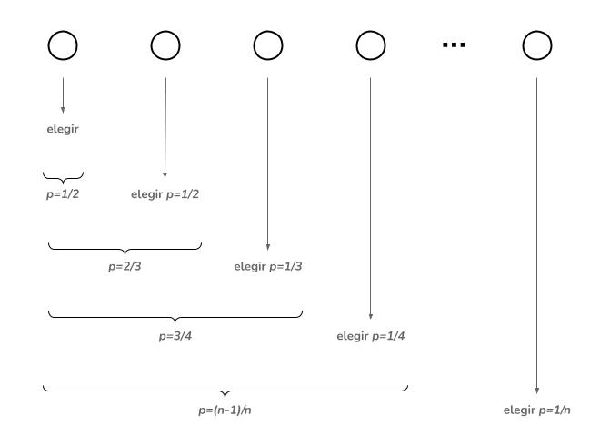

```r
N <- nrow(locs)
samp_size <- 1000
S <- locs[1:samp_size, ]
U <- runif(samp_size)
for(i in seq_len(nrow(locs[samp_size:N, ]))){
  i_max <- which.max(U)
  ut <- runif(1)
  if(ut < U[i_max]){
    S[i_max, ] <- locs[i+samp_size, ]
    U[i_max] <- ut
  }
}
```

Ejercicio 1.11

Implementa el algoritmo de muestreo de reserva.

Veamos si, en efecto, se puede decir que nuestra muestra ‘replica’ las características de la población.

Ejercicio 1.12

Obtén la proporción de localidades por entidad dentro de la muestra con respecto a la distribución de localidades por entidad en la población total. De la misma manera, compara la distribución de escolaridad promedio dentro de la muestra vs el total.

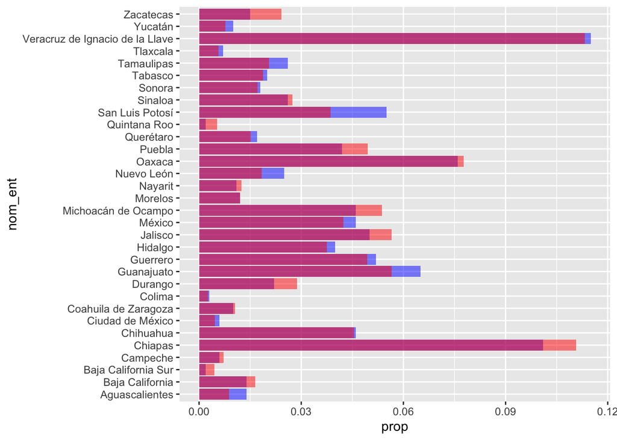

```r
ggplot(S) + geom_bar(aes(x=nom_ent, y = ..prop.., group = 1), stat = "count", fill='blue', alpha=.5) + geom_bar(data=locs, aes(x=nom_ent, y=..prop.., group=1), sat='count', fill='red', alpha=.5) + coord_flip()
```

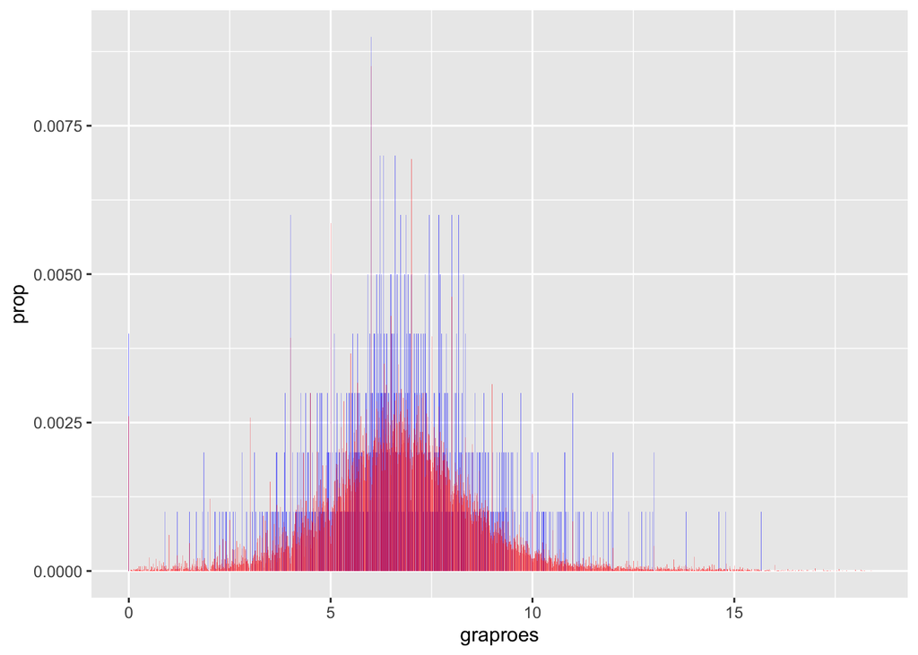

```r
ggplot(S) + geom_histogram(aes(x=graproes, y = ..prop.., group = 1), stat = "count", fill='blue', alpha=.5) + geom_bar(data=locs, aes(x=graproes, y=..prop.., group=1), sat='count', fill='red', alpha=.5)
```

**Nota importante:** No es necesario mantener el arreglo $U$, sólo se requiere la variable $W$.

Después de que la reserva se haya poblado con los primeros $n$ elementos, el arreglo $u$ contendría una muestra de $n$ valores de $U(0,1)$. $W$, por lo tanto, tiene la misma distribución que el valor más grande en una muestra de tamaño $n$ de $U(0, 1)$.

Subsecuentemente, el siguiente valor, $W'$, tiene la misma distribución que el valor más grande en una muestra de tamaño $n$ de $U(0,W)$.

Entonces, se conoce la distribución de $W$, pero ¿cómo se puede usar para generar un valor concreto como parte del algoritmo de muestreo? Bueno, ¡el cómo es bastante simple! Li proporciona la siguiente expresión para generar el valor más grande a partir de una muestra de tamaño $n$ de $U(0,b)$:

$X=U(0,b)$ $max(x_{1}, ..., x_{n}) = b * random()^{1/n} = b * exp(log(random())/n)$

Sin embargo, el por qué requiere algunas matemáticas relativamente involucradas que no se profundizarán aquí. Por ahora, supongamos que Li está en lo correcto y pasemos a describir el algoritmo $L$:

1. Poblar la reserva con los primeros $n$ elementos.
2. Establecer $W=exp(log(random())/n)$.
3. Establecer $S=⌊log(random())/log(1−W)⌋$.
4. Hasta que se agoten las entradas:
   1. Omitir los siguientes $S$ registros.
   2. Reemplazar un elemento aleatorio de la reserva con el registro $S+1$.
   3. Establecer $W=W∗exp(log(random())/n)$

Ejercicio 1.13

Implementa el algoritmo de muestreo de reserva optimizado.

```r
reservoir <- function(pop, n_res){
  res <- pop[1:n_res]
  res_prob <- exp(log(runif(1))/n_res)
  i <- n_res + 1
  while(i <= n){
    i <- i + floor(log(runif(1))/log(1 - replace_prob)) + 1
    if(i <= n){
      res[sample(n_res, 1)] <- pop[i]
      res_prob <- res_prob*exp(log(runif(1))/n_res)
    }
  }
  res
}
```